# MasterControl-EDA

April Greenwood

2026-02-21

## Business Problem

Master Control seeks to improve sales efficiency by identifying which Qualified Account Leads (QALs) are most likely to progress to SQL, SQO, or Won.

Understanding conversion drivers will allow the company to prioritize high-value leads, allocate sales resources efficiently, improve targeting by product and industry, and increase overall revenue conversion.

## Target Variable

**Target Variable:** `lead_success` 1 = Lead converted (SQL, SQO, or Won) 0 = Lead did not convert

Our objective is to model the probability of a lead being successful.

# Load Libraries and Data

```r
# Load libraries
library(tidyverse)
```

```r
library(readr)
library(dplyr)
library(ggplot2)
library(janitor)
library(tidyr)

# Load dataset
qal_data <- read_csv("C:/Users/green/Downloads/QAL Performance for MSBA.csv") %>%
  clean_names()
qal_analysis <- qal_data
```

```r
# Examine structure
str(qal_analysis)
```

```
## spc_tbl_ [16,815 × 14] (S3: spec_tbl_df/tbl_df/tbl/data.frame)
##  $ acct_primary_site_function  : chr [1:16815] "Food and beverage" "Small-molecule API" "Sterile injectables" "Sterile injectables" ...
##  $ acct_manufacturing_model    : chr [1:16815] "Consumer Packaged Goods" "In-House" "In-House" "In-House" ...
##  $ acct_target_industry        : chr [1:16815] "Non-Life Science" "Pharma & BioTech" "Pharma & BioTech" "Pharma & BioTech" ...
##  $ contact_lead_title          : chr [1:16815] "QA Manager" "VP Quality&Regulatory Affairs" "Qualified person" "Qualified person" ...
##  $ qal_id                      : chr [1:16815] "a0dPQ000005WbfuYAC" "a0dPQ000008ye7dYAA" "a0dPQ000000NRkHYAW" "a0dPQ000009DHVhYAO" ...
##  $ contact_lead_id             : chr [1:16815] "0030c00002XPeNGAA1" "0030c00002XR1uPAAT" "0030c00002Y3NUZAA3" "0030c00002Y3NUZAA3" ...
##  $ next_stage_c                : chr [1:16815] "SQL" "Recycled" "Recycled" "Recycled" ...
##  $ priority                    : chr [1:16815] "P1 - Webinar Demo" "No Priority" "Priority 2" "P1 - Webinar Demo" ...
##  $ acct_territory_rollup       : chr [1:16815] "Americas" "EMEA" "EMEA" "EMEA" ...
##  $ acct_tier_rollup            : chr [1:16815] "Medium" "Medium" "Small" "Small" ...
##  $ solution                    : chr [1:16815] "Mx" "Qx" "Qx" "Qx" ...
##  $ solution_rollup             : chr [1:16815] "Mx" "Qx" "Qx" "Qx" ...
##  $ last_tactic_campaign_channel: chr [1:16815] "Online Ads" "Outbound Prospecting" "Email" "Email" ...
##  $ qal_cohort_date             : Date[1:16815], format: "2025-06-16" "2025-09-19" ...
##  - attr(*, "spec")=
##   .. cols(
##   ..   `acct primary site function` = col_character(),
##   ..   `acct manufacturing model` = col_character(),
##   ..   `acct target industry` = col_character(),
##   ..   `contact/lead title` = col_character(),
##   ..   `QAL ID` = col_character(),
##   ..   `contact/lead id` = col_character(),
##   ..   next_stage__c = col_character(),
##   ..   Priority = col_character(),
##   ..   `acct territory rollup` = col_character(),
##   ..   `acct tier rollup` = col_character(),
##   ..   solution = col_character(),
##   ..   solution_rollup = col_character(),
##   ..   `last tactic campaign channel` = col_character(),
##   ..   `qal cohort date` = col_date(format = "")
##   .. )
##  - attr(*, "problems")=<externalptr>
```

```r
# Summary statistics
summary(qal_analysis)
```

```
##  acct_primary_site_function acct_manufacturing_model acct_target_industry
##  Length:16815               Length:16815             Length:16815
##  Class :character           Class :character         Class :character
##  Mode  :character           Mode  :character         Mode  :character
##
##
##
##  contact_lead_title    qal_id          contact_lead_id    next_stage_c
##  Length:16815       Length:16815       Length:16815       Length:16815
##  Class :character   Class :character   Class :character   Class :character
##  Mode  :character   Mode  :character   Mode  :character   Mode  :character
##
##
##
##    priority         acct_territory_rollup acct_tier_rollup     solution
##  Length:16815       Length:16815          Length:16815       Length:16815
##  Class :character   Class :character      Class :character   Class :character
##  Mode  :character   Mode  :character      Mode  :character   Mode  :character
##
##
##
##  solution_rollup    last_tactic_campaign_channel qal_cohort_date
##  Length:16815       Length:16815                 Min.   :2024-01-01
##  Class :character   Class :character             1st Qu.:2024-05-22
##  Mode  :character   Mode  :character             Median :2024-12-03
##                                                  Mean   :2024-12-02
##                                                  3rd Qu.:2025-06-05
##                                                  Max.   :2026-01-05
```

# Target variable

```r
colnames(qal_analysis)
```

```
##  [1] "acct_primary_site_function"   "acct_manufacturing_model"
##  [3] "acct_target_industry"         "contact_lead_title"
##  [5] "qal_id"                       "contact_lead_id"
##  [7] "next_stage_c"                 "priority"
##  [9] "acct_territory_rollup"        "acct_tier_rollup"
## [11] "solution"                     "solution_rollup"
## [13] "last_tactic_campaign_channel" "qal_cohort_date"
```

```r
unique(qal_analysis$next_stage_c)
```

```
## [1] "SQL"      "Recycled" "Won"      "SQO"      NA         "Exclude"  "Lost"
## [8] "MQL"      "INQ"
```

```r
qal_analysis <- qal_analysis %>%
  mutate(
    lead_success = case_when(
      next_stage_c %in% c("SQL", "SQO", "Won") ~ 1,
      next_stage_c %in% c("Lost", "Recycled", "Exclude", "MQL", "INQ") ~ 0,
      TRUE ~ NA_real_
    )
  )

qal_analysis <- qal_analysis %>%
  filter(!is.na(lead_success))

# Convert categorical variables to factors
qal_analysis$solution_rollup <- as.factor(qal_analysis$solution_rollup)
qal_analysis$acct_target_industry <- as.factor(qal_analysis$acct_target_industry)

# Calculate overall success rate
overall_summary <- qal_analysis %>%
  summarise(
    Total_Leads = n(),
    Successes = sum(lead_success),
    Conversion_Rate = round(100 * mean(lead_success), 2)
  )

overall_summary
```

```
## # A tibble: 1 × 3
##   Total_Leads Successes Conversion_Rate
##         <int>     <dbl>           <dbl>
## 1       16332      3014            18.4
```

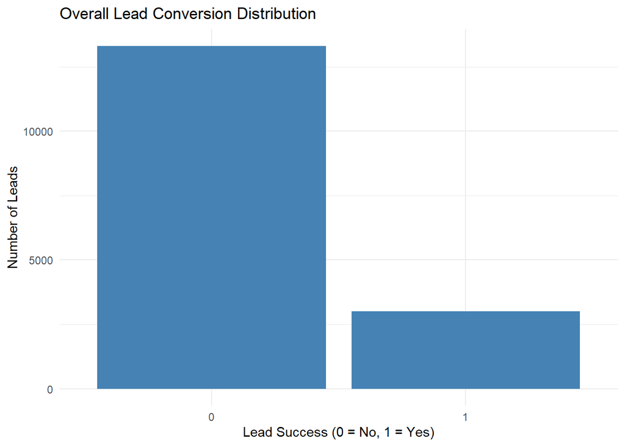

```r
ggplot(qal_analysis, aes(x = factor(lead_success))) +
  geom_bar(fill = "steelblue") +
  labs(
    title = "Overall Lead Conversion Distribution",
    x = "Lead Success (0 = No, 1 = Yes)",
    y = "Number of Leads"
  ) +
  theme_minimal()
```

The overall conversion rate is low, which means the data is imbalanced. Because of this, the model should be evaluated using metrics like AUC, recall, or precision instead of accuracy alone.

# Conversion by product family

```r
product_summary <- qal_analysis %>%
  group_by(solution_rollup) %>%
  summarise(
    Total_Leads = n(),
    Successes = sum(lead_success),
    Conversion_Rate = round(100 * mean(lead_success), 2),
    .groups = "drop"
  ) %>%
  arrange(desc(Conversion_Rate))

product_summary
```

```
## # A tibble: 3 × 4
##   solution_rollup Total_Leads Successes Conversion_Rate
##   <fct>                 <int>     <dbl>           <dbl>
## 1 Ax                       27         8            29.6
## 2 Qx                    12180      2473            20.3
## 3 Mx                     4125       533            12.9
```

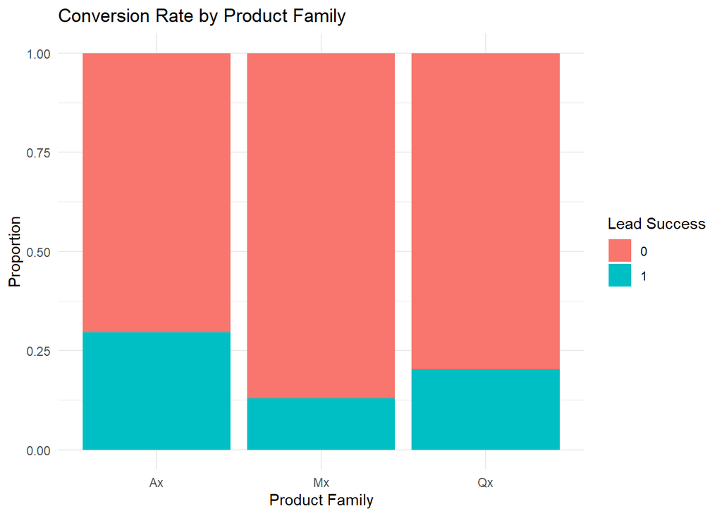

```r
ggplot(qal_analysis, aes(x = solution_rollup, fill = factor(lead_success))) +
  geom_bar(position = "fill") +
  labs(
    title = "Conversion Rate by Product Family",
    x = "Product Family",
    y = "Proportion",
    fill = "Lead Success"
  ) +
  theme_minimal()
```

Product family shows meaningful variation in conversion rates, suggesting that product may influence progression outcomes. This variable is likely to be a strong predictor in the model.

#conversion by industry

```r
industry_summary <- qal_analysis %>%
  group_by(acct_target_industry) %>%
  summarise(
    Total_Leads = n(),
    Successes = sum(lead_success),
    Conversion_Rate = round(100 * mean(lead_success), 2),
    .groups = "drop"
  ) %>%
  arrange(desc(Total_Leads))

industry_summary
```

```
## # A tibble: 6 × 4
##   acct_target_industry Total_Leads Successes Conversion_Rate
##   <fct>                      <int>     <dbl>           <dbl>
## 1 Pharma & BioTech            6192      1166           18.8
## 2 Non-Life Science            5732       918           16.0
## 3 Medical Device              3730       796           21.3
## 4 Blood & Biologics            461       109           23.6
## 5 Unknown                      174         6            3.45
## 6 <NA>                          43        19           44.2
```

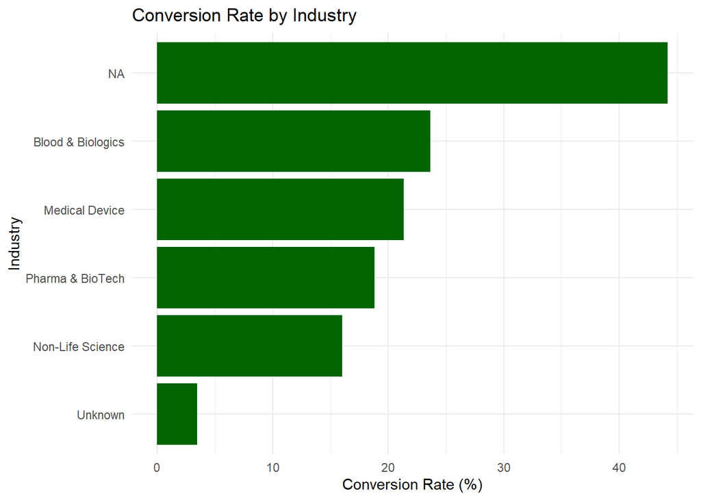

```r
ggplot(industry_summary,
       aes(x = reorder(acct_target_industry, Conversion_Rate),
           y = Conversion_Rate)) +
  geom_col(fill = "darkgreen") +
  coord_flip() +
  labs(
    title = "Conversion Rate by Industry",
    x = "Industry",
    y = "Conversion Rate (%)"
  ) +
  theme_minimal()
```

# Missing Data assassment and treatment

```r
missing_counts <- colSums(is.na(qal_analysis))
missing_counts
```

```
##   acct_primary_site_function     acct_manufacturing_model
##                         6663                         6661
##         acct_target_industry           contact_lead_title
##                           43                         6197
##                       qal_id              contact_lead_id
##                            0                            2
##                 next_stage_c                     priority
##                            0                            0
##        acct_territory_rollup             acct_tier_rollup
##                          127                           43
##                     solution              solution_rollup
##                            0                            0
## last_tactic_campaign_channel              qal_cohort_date
##                            0                            0
##                 lead_success
##                            0
```

```r
qal_analysis <- qal_analysis %>%
  mutate(
    across(
      c(acct_primary_site_function,
        acct_manufacturing_model,
        acct_target_industry,
        contact_lead_title,
        priority,
        acct_territory_rollup,
        acct_tier_rollup,
        solution,
        solution_rollup,
        last_tactic_campaign_channel),
      ~ ifelse(is.na(.), "Unknown", .)
    )
  )

qal_analysis <- qal_analysis %>%
  mutate(
    across(
      c(acct_primary_site_function,
        acct_manufacturing_model,
        acct_target_industry,
        contact_lead_title,
        priority,
        acct_territory_rollup,
        acct_tier_rollup,
        solution,
        solution_rollup,
        last_tactic_campaign_channel),
      as.factor
    )
  )


colSums(is.na(qal_analysis))
```

```
##   acct_primary_site_function     acct_manufacturing_model
##                            0                            0
##         acct_target_industry           contact_lead_title
##                            0                            0
##                       qal_id              contact_lead_id
##                            0                            2
##                 next_stage_c                     priority
##                            0                            0
##        acct_territory_rollup             acct_tier_rollup
##                            0                            0
##                     solution              solution_rollup
##                            0                            0
## last_tactic_campaign_channel              qal_cohort_date
##                            0                            0
##                 lead_success
##                            0
```

```r
nrow(qal_analysis)
```

```
## [1] 16332
```

**Interpretation**

Any variables with substantial missingness must be addressed prior to modeling. Options include: - Removing rows - Imputing values - Creating “Unknown” categories

# Questions Guiding Exploration

- What is the overall conversion rate?
- Does product family influence conversion?
- Does industry influence conversion?
- Are there sparse categories?
- Are there missing values?
- Do numeric predictors show skewness?
- Are some variables highly correlated?
- Which predictors appear strongest visually?

# Results and Key Insights

## Key Findings

The overall conversion rate indicates class imbalance. Product shows meaningful variation in conversion rates. Several industry categories appear to have low observation counts, which may produce unstable conversion estimates. These sparse categories may need consolidation prior to modeling.

## Data Issues Identified

- Class imbalance
- Potential sparse industry categories
- Possible missing values

## Impact on Modeling Strategy

Given the binary target and class imbalance:

- Logistic regression with class weighting could be useful
- Tree-based models may capture nonlinear relationships.
- Evaluation metrics should prioritize recall, precision, and AUC over accuracy.

The EDA suggests that product family and industry are promising predictors and should be retained in all candidate models.

# Conclusion

Exploratory Data Analysis reveals meaningful differences in conversion performance across product families and industries. The dataset is suitable for classification modeling, though careful preprocessing and imbalance handling will be required.

This EDA has clarified the modeling objective, identified potential data challenges, and informed the selection of appropriate predictive techniques.